# Regressão Linear Simples

### Caso 2: $a \neq b$ e $a,b \geq 1$

[figure not shown]

```r
p = seq(0,1, length=100)
plot(p, dbeta(p, 900, 100), ylab="Densidade", type ="l", col=4)
lines(p, dbeta(p, 90, 10), type ="l", col=3)
lines(p, dbeta(p, 30, 70), col=2)
legend(0.2,30, c("Beta(900,100)","Beta(90,10)","Beta(30,70)", "Beta(3,7)"),lty=c(1,1,1,1),col=c(4,3,2,1))
```

### Caso 3: $a,b <1$

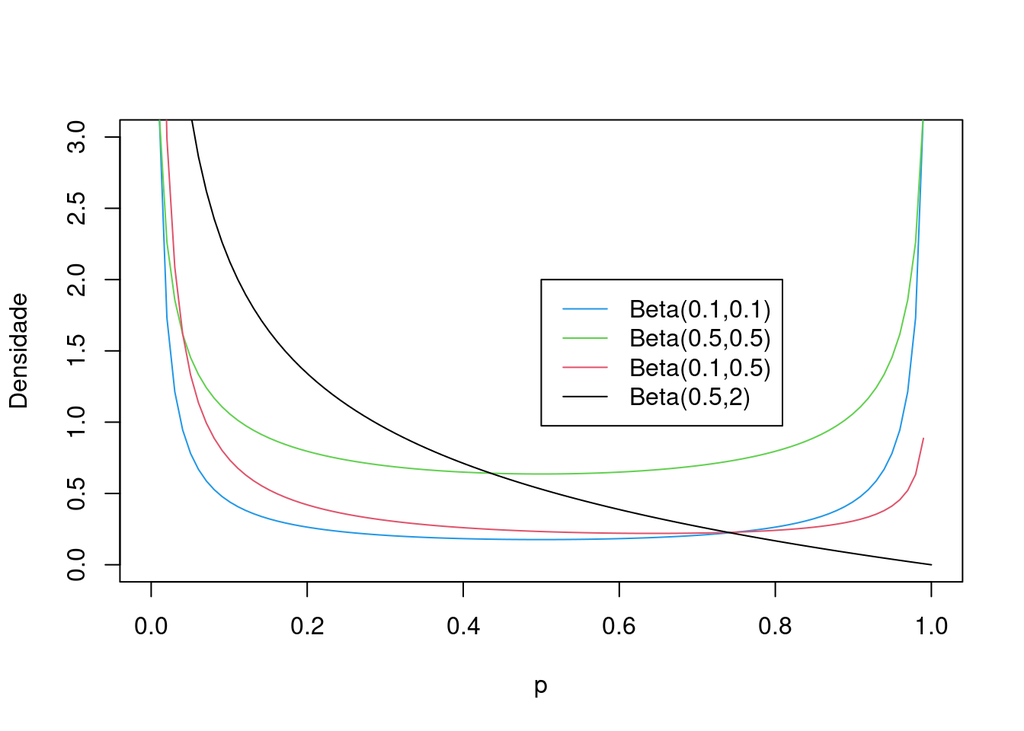

```r
p = seq(0,1, length=100)
plot(p, dbeta(p, 0.1, 0.1), ylim=c(0,3),ylab="Densidade", type ="l", col=4)
lines(p, dbeta(p, 0.5, 0.5), type ="l", col=3)
lines(p, dbeta(p, 0.1, 0.5), col=2)
lines(p, dbeta(p, 0.5, 2), col=1)
legend(0.5,2, c("Beta(0.1,0.1)","Beta(0.5,0.5)","Beta(0.1,0.5)", "Beta(0.5,2)"),lty=c(1,1,1,1),col=c(4,3,2,1))
```

### Caso 4: $a,b =1$

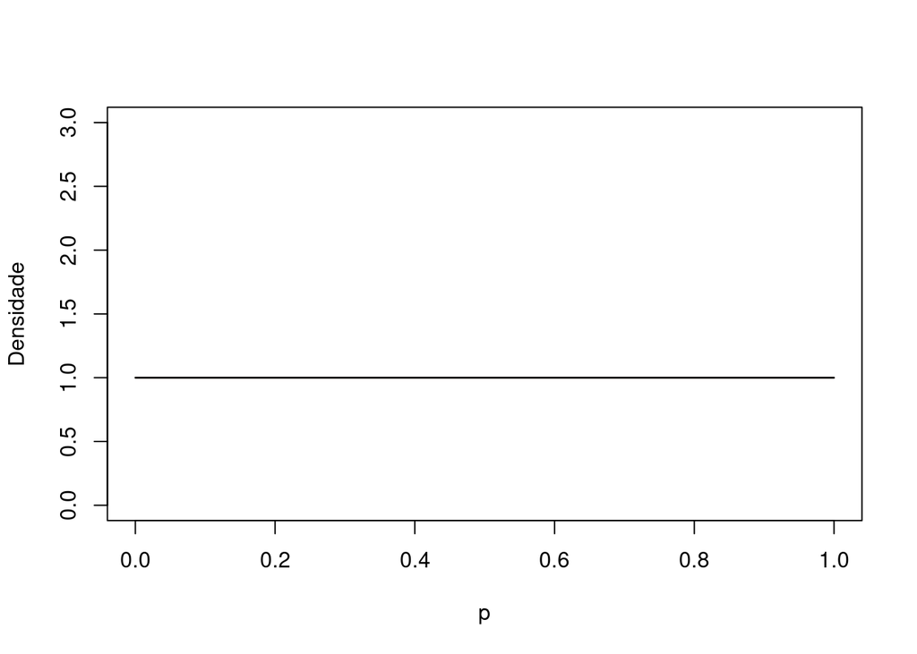

```r
p = seq(0,1, length=100)
plot(p, dbeta(p, 1, 1), ylim=c(0,3),ylab="Densidade", type ="l", col=4)
lines(p, dbeta(p, 1, 1), type ="l", col=3)
lines(p, dbeta(p, 1, 1), col=2)
lines(p, dbeta(p, 1, 1), col=1)
lines(p, dbeta(p, 1, 1), col=1)
```

Sejam $y_1, y_2,...,y_n$ variáveis aleatórias indenticamente distribuídas de uma distribuição Beta de parâmetros $a$ e $b \in \mathbb{R}_{+}$. Sendo $n$ amostras independentes a *função de verossimilhança* tem a seguinte forma:

$$\begin{equation}
L(\theta |\mathbf{y}) = \prod_{i=1}^{n}\dfrac{\Gamma(a+b)}{\Gamma(a)\Gamma(b)} y_{i}^{a-1}(1-y_i)^{b-1}
\end{equation}$$

como cada observação é independente, temos:

$$\begin{equation}
L(\theta |\mathbf{y}) = \left[\dfrac{\Gamma(a+b)}{\Gamma(a)\Gamma(b)} \right]^{n} \left[\sum_{i=1}^{n} y_i\right]^{a-1} \left[\sum_{i=1}^{n} 1 - y_i\right]^{b-1}
\end{equation}$$

Agora, vamos encontrar a *função de log-verossimilhança* $l(\theta |\mathbf{y})$.

$$\begin{equation}
l(\theta |\mathbf{y}) = nln(\Gamma(a+b)) - nln(\Gamma(a)) - nln(\Gamma(b)) + (a-1)\sum_{i=1} ^{n}ln(y_i) + (b-1)\sum_{i=1} ^{n}ln(1 - y_i).
\end{equation}$$

A função escore é obtida derivando a função $l(\theta|\mathbf{y})$ com respeito a $a$ e $b$, respectivamente,

$$\begin{equation}
S(a) = \dfrac{\partial }{\partial a}l(\theta |\mathbf{y}) = n \dfrac{\Gamma'(a,b)}{\Gamma(a,b)} - n \dfrac{\Gamma'(a)}{\Gamma(a)} + \sum_{i=1} ^{n}ln(y_i)
\end{equation}$$

onde $\psi(y) = \dfrac{\Gamma'(y)}{\Gamma(y)}$ é a função digamma. Logo,

$$\begin{equation}
S(a) = \psi(a,b) - \psi(a) + \dfrac{1}{n}\sum_{i=1} ^{n}ln(y_i)
\end{equation}$$

com respeito a $b$, temos:

$$\begin{equation}
S(b) = \dfrac{\partial }{\partial b}l(\theta |\mathbf{y}) = n \dfrac{\Gamma'(a,b)}{\Gamma(a,b)} - n \dfrac{\Gamma'(b)}{\Gamma(a)} + \sum_{i=1} ^{n}ln(1 - y_i)
\end{equation}$$

onde $\psi(x) = \dfrac{\Gamma'(x)}{\Gamma(x)}$ é a função digamma. Logo,

$$\begin{equation}
S(b)= \psi(a,b) - \psi(b) + \dfrac{1}{n}\sum_{i=1} ^{n}ln(1 - y_i)
\end{equation}$$

Igualando ambas as derivadas à zero e construindo o sistema, temos:

$$\begin{cases}
S(a) = \psi(a,b) - \psi(a) + \dfrac{1}{n}\sum_{i=1}^{n}ln(y_i) = 0\\
S(b) = \psi(a,b) - \psi(b) + \dfrac{1}{n}\sum_{i=1}^{n}ln(1 - y_i) = 0
\end{cases}$$

Não é possível explicitar, de forma analítica, a raiz do sistema composto pelas equações acima, se fazendo necessário utilizar métodos de otimização para aproximar o valor da estimativa de máxima verossimilhança, como por exemplo o Método de Newton Raphson.

Temos a informação observada dada por:

$$\begin{equation}
K(\widehat{\theta}) = \left[\begin{array}{cc}
\dfrac{\partial ^2}{\partial a^2}l(\theta |\mathbf{y}) & \dfrac{\partial^2}{\partial ab}l(\theta |\mathbf{y})\\
\dfrac{\partial^2}{\partial ba}l(\theta |\mathbf{y}) & \dfrac{\partial ^2 }{\partial b ^2}l(\theta |\mathbf{y})
\end{array}\right]
\end{equation}$$

onde:

$$\begin{align}
\dfrac{\partial ^2}{\partial a^2}l(\theta |\mathbf{y}) &= \psi'(a+b) - \psi'(a); \\
\dfrac{\partial^2}{\partial ab}l(\theta |\mathbf{y}) &= \dfrac{\partial^2}{\partial ba}l(\theta |\mathbf{y}) = \psi'(a+b); \\
\dfrac{\partial ^2 }{\partial b ^2}l(\theta |\mathbf{y}) &= \psi'(a+b) - \psi'(b); \\
\end{align}$$

Logo,

$$\begin{equation}
K(\theta) = \left[\begin{array}{cc}
\psi'(a+b) - \psi'(a) & \psi'(a+b) \\
\psi'(a+b) & \psi'(a+b) - \psi'(b)
\end{array}\right],
\end{equation}$$

## Teste de hipóteses

Definindo $\theta=(a,b)^\top$ como o vetor de parâmetros da distribuição *Beta* $X \sim Beta(a,b)$, temos que as hipóteses dos testes estatísticos são:

$$\begin{equation}
\mathcal{H_0}: \theta = [a_0, b_0]^\top \hspace{0.5cm} vs. \hspace{0.5cm} \mathcal{H_1}: \theta \neq [a_0, b_0]^\top.
\end{equation}$$

#### – A estatística da Razão de Verossimilhança é:

$$\begin{align*}
\text{RV} &=
2[\ell(\widehat{\theta} | \textbf{y}) - \ell(\widetilde{\theta}_0 | \textbf{y})]
\\&=
2\left[nlog\dfrac{\Gamma(\widehat{a}+\widehat{b})}{\Gamma(a_0 + b_0)}-nlog\dfrac{\Gamma(a_0)}{\Gamma(\widehat{a})}-nlog\dfrac{\Gamma(b_0)}{\Gamma(\widehat{b})}+(\widehat{a} - a_0)\sum_{i=0}^{n}log(y_i)+(\widehat{b} - b_0)\sum_{i=0}^{n}log(1-y_i)
\right].
\end{align*}$$

#### – A estatística Wald é dada por:

$$\begin{align*}
\mathcal{W} &= (\widehat{\theta} - \theta_0)^\top K(\widehat{\theta})^{-1} (\widehat{\theta} - \theta_0)
\end{align*}$$

em que $K(\widehat{\theta})^{-1}$ é a inversa da matriz de informação observada $p×p$, θˆ é o EMV do parâmetro $\theta$ e $\theta_0$ o valor sob a hipótese nula.

#### – A estatístia de teste Escore é dada por:

$$\begin{align*}
\operatorname{E} &= S(\theta_0)^\top
K^{-1}(\theta_0) S(\theta_0).
\end{align*}$$

em que $S(\theta) = \dfrac{\partial l(\theta)}{\partial \theta}$ é a função e $K(\theta)$ é a matriz de informação observada.

#### – Estimar os parâmetros numericamente com o pacote optim e método L-BFGS-B

#### – Função de log-verossimilhança

```r
ll_beta <- function(theta, x){
  ll <- dbeta(x, shape = theta[1], shape2  = theta[2], log = TRUE)
  return(-sum(ll))
}
```

#### – Estimar os parâmetros

```r
EMV <- optim(par = c(1, 1), fn = ll_beta, method = "L-BFGS-B",x=y)
print(EMV, hessian = TRUE)
```

```
## $par
## [1] 1.4601806 0.9046583
##
## $value
## [1] -9.176948
##
## $counts
## function gradient
##        9        9
##
## $convergence
## [1] 0
##
## $message
## [1] "CONVERGENCE: REL_REDUCTION_OF_F <= FACTR*EPSMCH"
```

```r
EMV <- as.list(EMV)
EMV1 <- EMV$par[1]
EMV2 <- EMV$par[2]
```

## Aplicação dos testes

Vamos considerar os testes de hipóteses para o vetor de parâmetro $\theta=(a,b)^\top$ da distribuição Beta com dois parâmetros, $X \sim Beta(a,b)$. As hipóteses dos testes estatísticos são:

$$\begin{equation}
\mathcal{H_0}: \theta = [1, 1.5]^\top \hspace{0.5cm} vs. \hspace{0.5cm} \mathcal{H_1}: \theta \neq [1, 1.5]^\top .
\end{equation}$$

#### Teste da Razão de Verossimilhança:

```r
RV <- function(Est, theta, a, ...){
  VC <- qchisq(1-a, df=length(theta))
  EC <- Est(theta, ...)
  print(ifelse(EC < VC, "Não rejeita H0", "Rejeita H0"))
  return(c(VC, EC))
}

EstRV <- function(theta, x, EMV){
  n <- length(x)
  a <- theta[1]
  b <- theta[2]
  aux1  <- n*(log(gamma(EMV1+EMV2))/(gamma(a+b)))
  aux2  <- n*(log(gamma(a)/gamma(EMV1)))
  aux3   <- n*(log(gamma(b)/gamma(EMV2)))
  aux4 <- (EMV1-a)*(sum(log(x)))
  aux5 <- (EMV2-b)*(sum(log(1-x)))
  lv <- 2*(aux1 - aux2 - aux2 + aux4 +aux5)
  return(lv)
}


RV(Est = EstRV, theta=c(1, 1.5), EMV=EMV$par, a = 0.05, x=y)
```

```
## [1] "Rejeita H0"
```

```
## [1]  5.991465 86.477641
```

#### Teste de Wald para distribuição de probabilidade com mais de um parâmetro:

```r
#### --Informação observada
IOW <- function(theta, x){
  n     <- length(x)
  a <- theta[1]
  b <- theta[2]
  Iaa   <- trigamma(a+b) - trigamma(a)
  Ibb   <- trigamma(a+b) - trigamma(b)
  Iab   <- trigamma(a+b)
  I <- matrix(c(Iaa, Iab, Iab, Ibb), nrow=2, ncol=2, byrow = TRUE)
  return(I)
}

#### -- Informação observada com respeito ao parâmetro $a$ usando o $\widehat{b}$ para $b$


IOWa <- function(theta,x){
  n     <- length(x)
  a <- theta[1]
  b  <- theta[2]
  Iaa   <- trigamma(a+b) - trigamma(a)
  return(-Iaa)
}

Wald2 <- function(theta, EMV, IO, a, ...){
  VC  <- qnorm(1-a/2)
  aux <- EMV - theta
  Tw  <- t(aux)%*%solve(IO(theta=EMV, ...))%*%aux
  if(Tw < 0)  print(ifelse(Tw > -VC, "Não rejeita H0", "Rejeita H0"))
  else  print(ifelse(Tw < VC, "Não rejeita H0", "Rejeita H0"))
  if(Tw < 0) return(c(Tw, -VC))
  else return(c(Tw, VC))
}

Wald2(theta=c(1, 1.5), EMV = EMV$par, IO = IOW, a=0.05, x=y)
```

```
##      [,1]
## [1,] "Não rejeita H0"
```

```
## [1] -0.480009 -1.959964
```

#### Teste Escore:

```r
Escore <- function(theta, S, IF, a, ...){
  VC <- qnorm(1-a/2)
  Te <- S(theta, ...)/sqrt(IF(theta, ...))
  print(ifelse(Te < VC, "Não rejeita H0", "Rejeita H0"))
  return(c(Te, VC))
}

#### --Função escore

FescB <- function(theta, x){
  n     <- length(x)
  a <- theta[1]
  b <- theta[2]
  esco1 <- digamma(a+b) - digamma(a) + (1/n)*(sum(log(x)))
  esco2 <- digamma(a+b) - digamma(b) + (1/n)*(sum(log(1-x)))
  return(c(esco1, esco2))
}

#### -- Função escore com respeito ao parâmetro $a$ usando o $\widehat{b}$ para $b$

FescBeta <- function(theta, x){
  n     <- length(x)
  a <- theta[1]
  b <- theta[2]
  esco1 <- digamma(a+b) - digamma(a) + (1/n)*(sum(log(x)))
  return(-esco1)
}

Escore(theta =  c(1, 1.5), S = FescBeta, IF = IOWa, a=0.05, x=y)
```

```
## [1] "Não rejeita H0"
```

```
## [1] -0.5996587  1.9599640
```

#### – Aplicação dos testes para o parâmetro de forma $a$

Vamos considerar os testes de hipóteses para o vetor de parâmetro de forma $a$ da distribuição Beta com dois parâmetros, $X \sim Beta(a,b)$. As hipóteses dos testes estatísticos são:

$$\begin{equation}
\mathcal{H_0}: a = a_0 \hspace{0.5cm} vs. \hspace{0.5cm} \mathcal{H_1}: a \neq a_0 .
\end{equation}$$

#### – Teste RV

```r
RV(Est = EstRV, theta = c(1, EMV$par[2]), EMV=EMV$par, a = 0.05, x=y)
```

```
## [1] "Não rejeita H0"
```

```
## [1]   5.991465 -66.810443
```

#### – Teste Wald

```r
Wald2(theta = c(1, EMV$par[2]), EMV = EMV$par, IO = IOW, a=0.05, x=y)
```

```
##      [,1]
## [1,] "Não rejeita H0"
```

```
## [1] -0.8620966 -1.9599640
```

#### – Teste Escore

```r
Escore(theta =  c(1, EMV2), S = FescBeta, IF = IOWa, a=0.05, x=y)
```

```
## [1] "Não rejeita H0"
```

```
## [1] -0.3069112  1.9599640
```

#### – Intervalo de Confiança

Para obter os intervalos de confiança assintótico basta inverter a matriz de informação observada porque não temos a esperada e pegar os termos em sua diagonal que corresponde a variância de $\widehat{a}$ e $\widehat{b}$.

```r
Inf_Obs <- IOW(theta = EMV$par, x=y)
print(Inf_Obs)
```

```
##            [,1]       [,2]
## [1,] -0.4444930  0.5244663
## [2,]  0.5244663 -1.3832638
```

```r
DP   <- sqrt(diag(solve(-Inf_Obs)))
IC_a <- EMV$par[1] + c(-1, 1)*qnorm(1-0.05/2)*DP[1]
IC_b <- EMV$par[2] + c(-1, 1)*qnorm(1-0.05/2)*DP[2]
IC   <- rbind(IC_a, IC_b)
colnames(IC) <- c("2,5%", "97,5%")
print(IC)
```

```
##           2,5%    97,5%
## IC_a -2.494375 5.414737
## IC_b -1.337043 3.146359
```

#### – Gráfico da função de log-verossimilhança para o parâmetro $a$

#### – Função de log-verossimilhança

```r
ll_Be <- function(a, x){
  ll <- dbeta(x, shape1 = a, shape2 = EMV$par[2], log = TRUE)
  return(sum(ll))
}
```

#### – Gerar uma sequência de valores para $a$ e calcular $ℓ(a|\mathbf{y})$ para cada um dos valores

```r
alpha_vals <- seq(1, 10, len = 100)
Lalpha <- sapply(alpha_vals, ll_Be, x = y)
```

#### – Agora temos o gráfico da função de log-verossimilhança com respeito ao parâmetro $a$

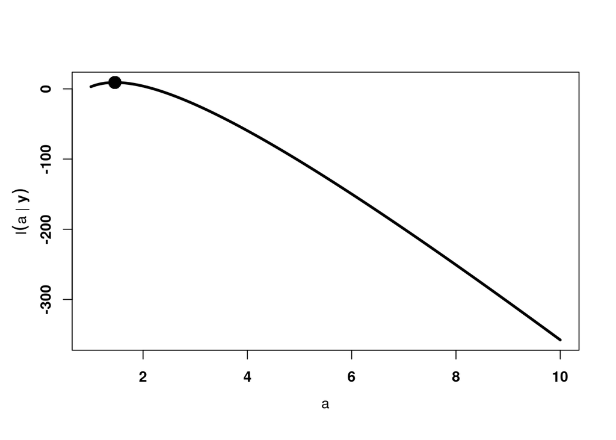

```r
plot(alpha_vals, Lalpha, type="l", lwd = 3.0, ylab="", xlab="", font =2)
mtext(expression(l(a~"|"~bold(y))), 2, line=2.2, cex=1, font=2)
mtext(expression(a), 1, line=2.5,    cex=1, font=2)
points(EMV$par[1], max(Lalpha), cex = 2, pch =16)
```